# AML-3104 Assignment 1

### [30 Marks, 20%]

### Team Name: PyCoders

Team Members:

1. Bhanu Prakash Mahadevuni – C0850515
2. Deeksha Naikap – C0835440
3. Pramod Reddy Gurrala – C0850493
4. Sai Varun Kollipara – C0828403

## Import libraries

```python
import numpy as np
import matplotlib.pyplot as plt
# You may need some sklearn specific imports, or other standard toolboxes
```

## Load dataset

```python
trainingset = np.loadtxt('training.csv', delimiter=',')
testingset = np.loadtxt('test.csv', delimiter=',')

trainingset
```

```
array([[ 70.,  80.,  82., ...,   0.,   0.,   0.],
       [151., 150., 147., ...,   0.,   0.,   0.],
       [231., 212., 156., ...,   0.,   0.,   0.],
       ...,
       [ 74.,  81.,  87., ...,   1.,   0.,   0.],
       [222., 227., 203., ...,   0.,   0.,   0.],
       [195., 199., 205., ...,   1.,   0.,   0.]])
```

## Split data

```python
n_inputs = 2304 # images are 48 x 48
n_classes = 7 # 7 classes - as defined below
img_dim = 48 # each input image dimension, width and height are both 48

x_training = trainingset[:, 0:n_inputs] # Extract the first 2304 elements - the image
y_training = trainingset[:, n_inputs:n_inputs + n_classes] # Extract the last 7 elements - a one hot category encoding

x_testing = testingset[:, 0:n_inputs] # Extract the first 2304 elements - the image
y_testing = testingset[:, n_inputs:n_inputs + n_classes] # Extract the last 7 elements - a one hot category encoding

x_training = x_training.reshape(x_training.shape[0], 48, 48) # Make samples image shaped
x_testing = x_testing.reshape(x_testing.shape[0], 48, 48) # Make samples image shaped
```

```python
def get_emotion(whichemotion):
    if whichemotion.shape[0] == 1:
        indx = whichemotion[0]
    else:
        indx = np.argmax(whichemotion)
    if indx == 0:
        return 'angry'
    elif indx == 1:
        return 'disgust'
    elif indx == 2:
        return 'fear'
    elif indx == 3:
        return 'happy'
    elif indx == 4:
        return 'sad'
    elif indx == 5:
        return 'surprise'
    elif indx == 6:
        return 'neutral'
```

```
(28709, 48, 48)
(28709, 7)
(3589, 48, 48)
(3589, 7)
```

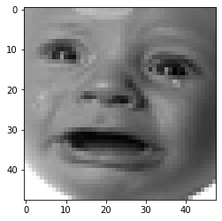

```
facial emotion: sad
```

```python
print(x_training.shape)
print(y_training.shape)

print(x_testing.shape)
print(y_testing.shape)

sampleindex = np.random.randint(0,1000)
sample = x_training[sampleindex, :]
sample = sample.reshape(48, 48)

plt.imshow(sample, cmap='gray')
plt.show()
print('facial emotion: %s' % get_emotion(y_training[sampleindex, :]))
```

# Part I : Happy or Sad

## For this part you will consider a binary classification problem - categorizing faces as happy or sad

[1 Mark] a. Sample from the data loaded above to include only the happy or sad cases

```python
## Scaling the data
x_training = x_training/255
x_testing = x_testing/255
```

```python
# Convert one-hot encoded labels into real-label names
y_training = np.apply_along_axis(get_emotion,1,y_training)
y_testing = np.apply_along_axis(get_emotion,1,y_testing)
```

```python
# Sampling training data to include only happy or sad
happy_sad_train_index = np.any([y_training == 'happy',y_training == 'sad'],axis=0).nonzero()[0]
happy_sad_train_y = y_training[happy_sad_train_index]
happy_sad_train_X = x_training[happy_sad_train_index]

# Sampling training data to include only happy or sad
happy_sad_test_index = np.any([y_testing == 'happy',y_testing == 'sad'],axis=0).nonzero()[0]
happy_sad_test_y = y_testing[happy_sad_test_index]
happy_sad_test_X = x_testing[happy_sad_test_index]

# Converting labels into numerical values (to evaluate and visualize- some metrics works only with numericals)
happy_sad_train_y = (happy_sad_train_y == 'happy').astype(int)
happy_sad_test_y = (happy_sad_test_y == 'happy').astype(int)
```

```python
print(f'Training data {happy_sad_train_X.shape} and {happy_sad_train_y.shape}')
print(f'Testing data {happy_sad_test_X.shape} and {happy_sad_test_y.shape}')
```

```
Training data (12045, 48, 48) and (12045,)
Testing data (1548, 48, 48) and (1548,)
```

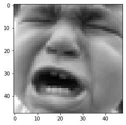

```
facial emotion: Sad
```

```python
# Print a sample image from the sampled dataset
sampleindex = np.random.randint(0,happy_sad_train_X.shape[0])
sample = happy_sad_train_X[sampleindex, :]

emotion = 'Happy' if happy_sad_train_y[sampleindex] == 1 else 'Sad'
plt.imshow(sample, cmap='gray')
plt.show()
print('facial emotion: %s' % emotion)
```

[4 Marks] b. Apply PCA and LDA to represent the faces, display a sample of a few faces for each case. You may consider using one or both of these in the steps that follow if they are of any value (this is for you to decide).

Dimensionality reduction is a technique used to reduce the number of features or variables in a dataset while preserving as much information as possible. It involves transforming a high-dimensional dataset into a lower-dimensional representation that retains the most important features of the original data.

Two main algorithms in dimentionlity reduction are:

- Principle Component Analysis (PCA)
- Linear Discriminant Analysis (LDA)

## PCA

Principal Component Analysis (PCA) is a commonly used unsupervised linear transformation technique. It reduces the number of dimensions by finding the maximum variance in high dimensional data. PCA reduces the number of dimensionality of the dataset.

```python
# Convert the array to 2-d
happy_sad_2d = happy_sad_train_X.reshape(happy_sad_train_X.shape[0], -1)
```

```python
from sklearn.decomposition import PCA

# Account for 99% of variance
pca_binary = PCA(0.99)
# Transformed image
image_transformed = pca_binary.fit_transform(happy_sad_2d)

print(f'{happy_sad_2d.shape[1]} features has been reduced to {image_transformed.shape[1]}')
```

```
2304 features has been reduced to 835
```

> Variance refers to the amount of variability in a data set that can be attributed to each individual principal component. We have performed PCA on the 2-d array to account for 99% of variance, i.e the transformed image can represent the 99% of the information of the original data. We were able to capture 99% variance with 835 principal components or features.

We are going to display the difference between the PCA transformed data and the original data. To do that, we will inverse transform the PCA transformed 2-d array data. And then reshape the 2-d array to 3-d, so that it matches with the original data.

```python
# Inverese the PCA transformed to original for display
inversed_2d = pca_binary.inverse_transform(image_transformed)
inveresed_3d = inversed_2d.reshape(inversed_2d.shape[0], 48, 48)
```

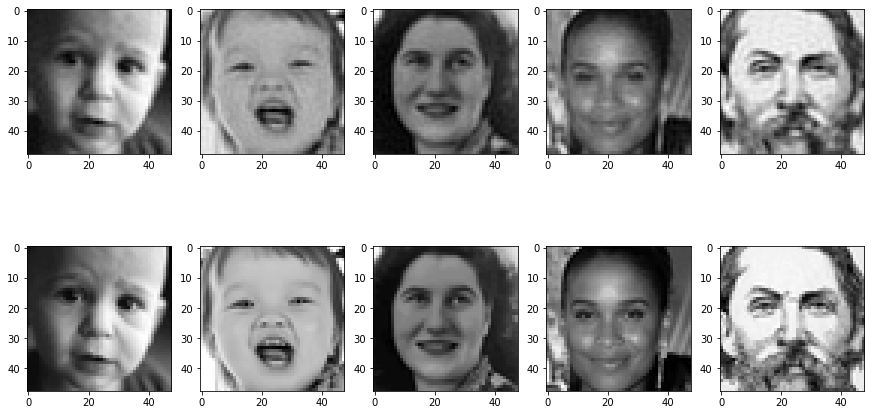

```python
import random

# Compare and display 5 inversed PCA images and its original images
randomlist = random.sample(range(0,inveresed_3d.shape[0]), 5)

plt.figure(figsize=(15,8))
for i in range(5):
    plt.subplot(2,5,i+1)
    plt.imshow(inveresed_3d[randomlist[i], :], cmap='gray')
    plt.subplot(2,5,i+6)
    plt.imshow(happy_sad_train_X[randomlist[i], :], cmap='gray')
plt.show()
```

The top 5 images are the PCA inverse transformed images, whereas the bottom 5 are the original ones. It is evident that the top 5 images from the PCA transormation have lost certain clarity due to the reduction technique.

## LDA

Linear Discriminant Analysis (LDA) is a supervised method that takes class labels into account when reducing the number of dimensions. The goal of LDA is to find a feature subspace that best optimizes class separability. In LDA it reduces the features to (number of classes - 1) features.

In our happy_sad_2d dataset, we have 2 classes:happy and sad. So LDA reduces the features to 1 feature(2-1).

```python
from sklearn.discriminant_analysis import LinearDiscriminantAnalysis

# Perform LDA on the sampled dataset
lda = LinearDiscriminantAnalysis()
lda.fit(happy_sad_2d, happy_sad_train_y)
lda_transformed = lda.transform(happy_sad_2d)

print(f'{happy_sad_2d.shape[1]} features has been reduced to {lda_transformed.shape[1]}')
```

```
2304 features has been reduced to 1
```

As we have only one feature for a image, it will be hard to visualize and display the reduced features. Also it is hard to inverse the LDA transformed images.

We are going to use pinv function of numpy to inverse the LDA transformed image back to the original one. If the determinant of the array is zero it will not have an inverse and the inv function will not work. But pinv will. This is because pinv returns the inverse of the array when it is available and the pseudo inverse when it isn't. That is the reason for us to use pinv over inv function.

Using pinv function, we are going to get the approximate inverse for numerical data, eventhough it is not possible to inverse the image data.

```python
from sklearn.utils.validation import check_is_fitted
from sklearn.utils import check_array, check_X_y

# Perform inverse transform on LDA
def inverse_transform(lda, x):
    if lda.solver == 'lsqr':
        raise NotImplementedError("(inverse) transform not implemented for 'lsqr' "
                                  "solver (use 'svd' or 'eigen').")
    check_is_fitted(lda, ['xbar_', 'scalings_'], all_or_any=any)

    # Numpy's pinverse
    inv = np.linalg.pinv(lda.scalings_)

    x = check_array(x)
    # Perform operation based on the type of solver
    if lda.solver == 'svd':
        x_back = np.dot(x, inv) + lda.xbar_
    elif lda.solver == 'eigen':
        x_back = np.dot(x, inv)

    return x_back
```

```python
# Perform inverse transform
inversed_lda = inverse_transform(lda,lda_transformed)
inversed_lda
```

```
array([[0.44904046, 0.43968253, 0.43188559, ..., 0.42342814, 0.4266329 ,
        0.42904464],
       [0.44841507, 0.4403948 , 0.43052565, ..., 0.42368275, 0.42647637,
        0.42855817],
       [0.44833711, 0.4404836 , 0.43035611, ..., 0.42371449, 0.42645686,
        0.42849753],
       ...,
       [0.4477055 , 0.44120294, 0.42898266, ..., 0.42397163, 0.42629878,
        0.42800623],
       [0.44829212, 0.44053483, 0.4302583 , ..., 0.42373281, 0.4264456 ,
        0.42846254],
       [0.44838588, 0.44042805, 0.43046216, ..., 0.42369464, 0.42646907,
        0.42853546]])
```

> From the result of the LDA inversed transformation, it is vsible that all the values are more or less same.

Below is the visualization of 2 different elements(0th and 1000th) from the inverse transformed LDA dataset.

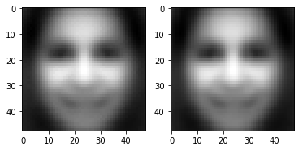

```python
# Visulaize two different images
lda_iveresed_3d = inversed_lda.reshape(inversed_lda.shape[0], 48, 48)
plt.subplot(1,2,1)
plt.imshow(lda_iveresed_3d[0], cmap='gray')
plt.subplot(1,2,2)
plt.imshow(lda_iveresed_3d[1000], cmap='gray')
plt.show()
```

> From the result, the comparison of two different elements from the inverse transformed LDA doesn't show any difference.

We are going to display the difference between the LDA transformed data and the original data. To do that, we will use the LDA inverse transformed 3-d array data lda_inveresed_3d, and the original happy_sad_train_X dataset.

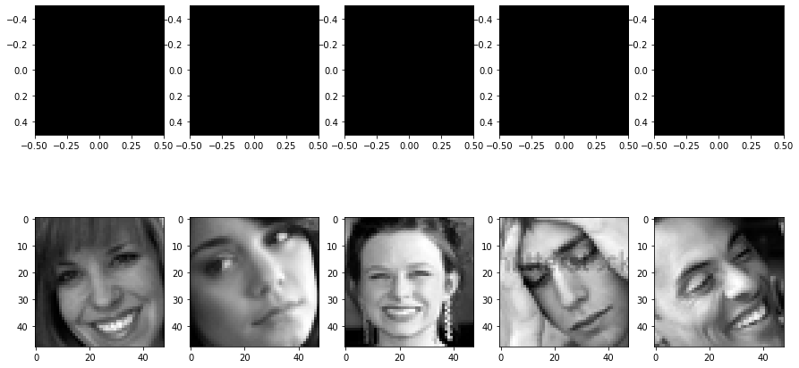

```python
#Visulaize the LDA value
randomlist = random.sample(range(0,lda_iveresed_3d.shape[0]), 5)

plt.figure(figsize=(15,8))
for i in range(5):
    plt.subplot(2,5,i+1)
    plt.imshow(lda_transformed[randomlist[i]].reshape(1,-1), cmap='gray')
    plt.subplot(2,5,i+6)
    plt.imshow(happy_sad_train_X[randomlist[i], :], cmap='gray')
plt.show()
```

> It is evident that, the visulaization of any image from the LDA transformed dataset gives out a black image like the ones we have recieved above. Which means, it resulted in a lot of information loss as the dimension is reduced to 1 from 2304. Also it is almost impossible to reconstruct the image from that.

[2 Marks] c. Apply naive Bayes to classify faces as happy or sad. Report your accuracy.

In the above steps we have preprocessed the traing data (happy_sad_train_X) by applying PCA and LDA techniques. In order to evaluate the model we are going to build, the test dataset also has to be undergone the same dimensionality reduction techniques.

```python
# Transform the test set
test_pca_x = pca_binary.transform(happy_sad_test_X.reshape(happy_sad_test_X.shape[0],-1))
test_lda_x = lda.transform(happy_sad_test_X.reshape(happy_sad_test_X.shape[0],-1))
```

Below is the model evaluation function, which can be called later to visualize the evaluation steps of all the models.

```python
from sklearn.metrics import confusion_matrix
import seaborn as sns
import pandas as pd
from sklearn import metrics

# Visualize the model evaluation
def model_evaluation(pca_model, lda_model,test_pca_x,test_lda_x,happy_sad_test_y):
    # Predict on test set
    pca_prediction = pca_model.predict(test_pca_x)
    lda_prediction = lda_model.predict(test_lda_x)

    # Plot confusion matrix of PCA
    plt.figure(figsize=(15,5))
    plt.subplot(1,2,1)
    cmatrix_pca = confusion_matrix(happy_sad_test_y,pca_prediction)
    sns.heatmap(pd.DataFrame(cmatrix_pca,columns=['Happy','Sad'],index=['Happy','Sad']), annot=True, fmt='g')

    plt.ylabel('Actual label')
    plt.xlabel('Predicted label')
    plt.title('PCA model')

    # Plot confusion matrix of LDA
    plt.subplot(1,2,2)
    cmatrix_lda = confusion_matrix(happy_sad_test_y,lda_prediction)
    sns.heatmap(pd.DataFrame(cmatrix_lda,columns=['Happy','Sad'],index=['Happy','Sad']), annot=True, fmt='g')

    plt.ylabel('Actual label')
    plt.xlabel('Predicted label')
    plt.title('LDA model')

    # Calculate and print the accuracy
    print(f'Accuracy of the model trained with PCA is {metrics.accuracy_score(happy_sad_test_y, pca_prediction)*100:.2f}%')
    print(f'Accuracy of the model trained with LDA is {metrics.accuracy_score(happy_sad_test_y, lda_prediction)*100:.2f}%')
```

The Naive Bayes classifier is a supervised machine learning algorithm, which is used for classification tasks. One of the classifiers is Gaussian Naive Bayes, in which continuous values associated with each feature are assumed to be distributed according to a Gaussian distribution.

Wre will also create few lists to hold the model names, model pca and model lda, in order to compare the models in upcoming steps.

```python
from sklearn.naive_bayes import GaussianNB

# Models list (To compare the models at step f)
model_name = []
models_pca_list = []
models_lda_list = []

## Training the model
# Training with PCA data
model_name.append('Naive Bayes')
nb_pca = GaussianNB()
nb_pca.fit(image_transformed,happy_sad_train_y)
models_pca_list.append(nb_pca)

# Training with LDA data
nb_lda = GaussianNB()
nb_lda.fit(lda_transformed,happy_sad_train_y)
models_lda_list.append(nb_lda)
```

```
Accuracy of the model trained with PCA is 55.88%
Accuracy of the model trained with LDA is 67.51%
```

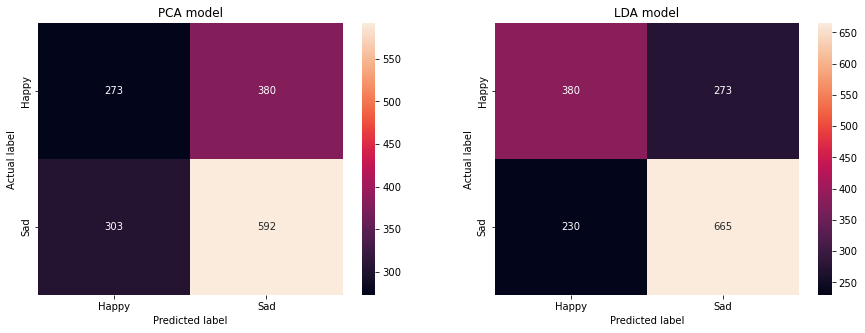

```python
# Visualize the evaluation
model_evaluation(nb_pca, nb_lda,test_pca_x,test_lda_x,happy_sad_test_y)
```

[2 Marks] d. Apply Logistic regression to classify faces as happy or sad. Report the accuracy.

Logistic regression is a Machine Learning model mainly used for binary classification problems due to its nature, because the main idea is to use regression to solve a classification problem. It works better when the target variable is categorical and discrete in nature.

```python
from sklearn.linear_model import LogisticRegression

## Training the model
# Training with PCA data
model_name.append('Logistic Regression')
lr_pca = LogisticRegression(solver = 'lbfgs', max_iter=1000)
lr_pca.fit(image_transformed,happy_sad_train_y)
models_pca_list.append(lr_pca)

# Training with LDA data
lr_lda = LogisticRegression(solver = 'lbfgs', max_iter=1000)
lr_lda.fit(lda_transformed,happy_sad_train_y)
models_lda_list.append(lr_lda)
```

```
Accuracy of the model trained with PCA is 70.67%
Accuracy of the model trained with LDA is 67.31%
```

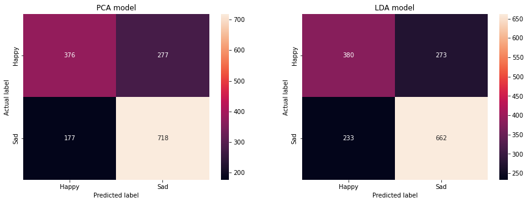

```python
# Visualize the evaluation
model_evaluation(lr_pca, lr_lda,test_pca_x,test_lda_x,happy_sad_test_y)
```

[2 Marks] e. Apply a Support Vector Machine to classify the faces as happy or sad. Choose parameters / arguments to try to maximize your accuracy. Report the accuracy.

Support vector machines classifier is a supervised algorithm that is capable of performing binary and multi-class classification on a dataset.

Both PCA and LDA data will be used to train the model.

```python
from sklearn.model_selection import RandomizedSearchCV
from sklearn.svm import SVC

# Parameters to be considered
param_grid = {'C': [0.1,1, 10], 'gamma': [1,0.1,0.01],'kernel': ['rbf', 'poly', 'sigmoid']}

# Find a model with better accuracy
pca_svc = SVC(probability=True)
pca_random_search = RandomizedSearchCV(pca_svc,
                        param_distributions=param_grid,
                        scoring='accuracy',
                        cv=3,
                        verbose=20,
                        n_jobs=-1)

pca_random_search.fit(image_transformed,happy_sad_train_y)
pca_svc = pca_random_search.best_estimator_
```

```
Fitting 3 folds for each of 10 candidates, totalling 30 fits
```

```python
lda_svc = SVC(probability=True)
lda_random_search = RandomizedSearchCV(lda_svc,
                        param_distributions=param_grid,
                        scoring='accuracy',
                        cv=3,
                        verbose=20,
                        n_jobs=-1)

lda_random_search.fit(lda_transformed,happy_sad_train_y)
lda_svc = lda_random_search.best_estimator_
```

```
Fitting 3 folds for each of 10 candidates, totalling 30 fits
```

```python
print('='*50)
print('Model trained with PCA data')
print("best estimator: " + str(pca_random_search.best_estimator_))
print("best params: " + str(pca_random_search.best_params_))
print('best score:', pca_random_search.best_score_)
print('='*50)
print('='*50)
print('Model trained with LDA data')
print("best estimator: " + str(lda_random_search.best_estimator_))
print("best params: " + str(lda_random_search.best_params_))
print('best score:', lda_random_search.best_score_)
print('='*50)
```

```
==================================================
Model trained with PCA data
best estimator: SVC(C=0.1, gamma=0.1, kernel='poly', probability=True)
best params: {'kernel': 'poly', 'gamma': 0.1, 'C': 0.1}
best score: 0.6997924449979244
==================================================
==================================================
Model trained with LDA data
best estimator: SVC(C=1, gamma=1, probability=True)
best params: {'kernel': 'rbf', 'gamma': 1, 'C': 1}
best score: 0.7920298879202989
==================================================
```

The model names, model pca and model lda details for the SVM alogorithm also will be added in the lits, in order to compare the models in upcoming steps.

```python
# Write the model to the list
model_name.append('SVM')
models_pca_list.append(pca_svc)
models_lda_list.append(lda_svc)
```

```
Accuracy of the model trained with PCA is 71.77%
Accuracy of the model trained with LDA is 66.93%
```

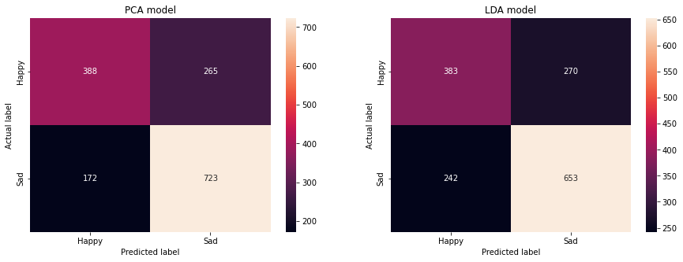

```python
# Visualize the evaluation
model_evaluation(pca_svc,lda_svc,test_pca_x,test_lda_x,happy_sad_test_y)
```

[1 Mark] f. Which of the approaches above allow you to reliably determine the degree of happiness or sadness (i.e. how happy or how sad)? Which do you trust the most?

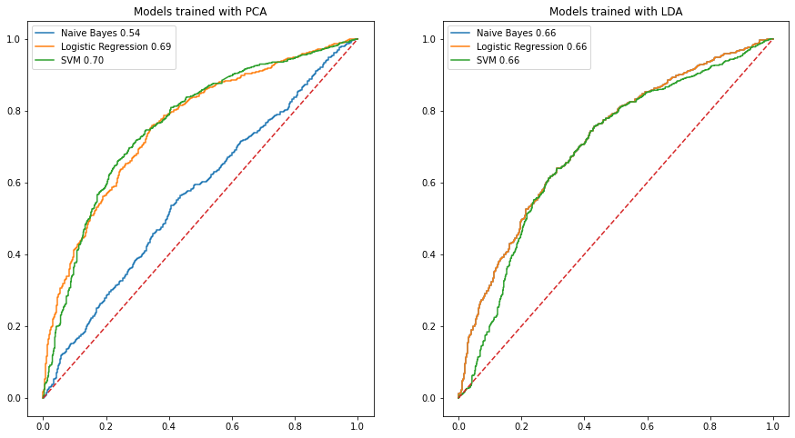

```python
from sklearn.metrics import roc_curve
from sklearn.metrics import roc_auc_score


# Plot ROC curve for PDA
plt.figure(figsize=(15,8))
plt.subplot(1,2,1)
# Plot the roc graph
for idx, model in enumerate(models_pca_list):
    fpr, tpr, thresholds = roc_curve(happy_sad_test_y,model.predict_proba(test_pca_x)[:,1])
    roc = roc_auc_score(happy_sad_test_y,model.predict(test_pca_x))
    plt.plot(fpr, tpr, label=f'{model_name[idx]} {roc:.2f}')

plt.plot([0, 1], [0, 1],linestyle='--')
plt.legend()
plt.title('Models trained with PCA')

# Plot ROC curve for LDA
plt.subplot(1,2,2)
# Plot the roc graph
for idx, model in enumerate(models_lda_list):
    fpr, tpr, thresholds = roc_curve(happy_sad_test_y,model.predict_proba(test_lda_x)[:,1])
    roc = roc_auc_score(happy_sad_test_y,model.predict(test_lda_x))
    plt.plot(fpr, tpr, label=f'{model_name[idx]} {roc:.2f}')

plt.plot([0, 1], [0, 1],linestyle='--')
plt.legend()
plt.title('Models trained with LDA')
plt.show()
```

[2 Marks] g. Based on your answer to f. show the 5 happiest faces and the 5 saddest faces.

```
Sad faces
```

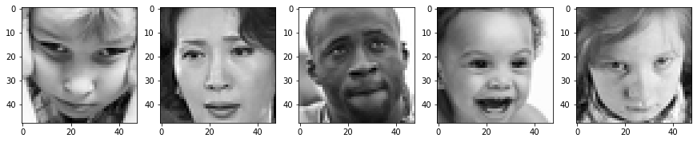

```
Happy faces
```

[figure not shown]

```python
# Display 5 happy and sad faces from test set
prediction = lr_pca.predict(test_pca_x)
sad_index = np.argwhere(prediction == 0)
happy_index = np.argwhere(prediction == 1)

random_sad = random.sample(list(sad_index.reshape(-1)), 5)
random_happy = random.sample(list(happy_index.reshape(-1)), 5)

plt.figure(figsize=(15,8))
print('Sad faces')
for i in range(5):
    plt.subplot(1,5,i+1)
    plt.imshow(happy_sad_test_X[random_sad[i]], cmap='gray')
plt.show()

plt.figure(figsize=(15,8))
print(f'Happy faces')
for i in range(5):
    plt.subplot(1,5,i+1)
    plt.imshow(happy_sad_test_X[random_happy[i]], cmap='gray')
plt.show()
```

# Part II : Multi-class

## For this part you will repeat the tasks in Part I, but instead consider the multi-class problem and classify inputs according to all 7 classes.

[4 Marks] a. Apply PCA and LDA to represent the faces, display a sample of a few faces for each case. Produce a plot for PCA showing the cumulative variance captured by adding additional principal components (e.g. 1st PC, 1st + 2nd PC, etc.). On the same figure, plot the same curve for only happy and sad faces used in part 1.

## PCA

We are going to perform PCA on the original dataset with all 7 classes ('angry','disgust','fear','happy','sad','surprise', and 'neutral') to account for 99% of the variance.

```python
# Convert the array to 2-d
x_training_2d = x_training.reshape(x_training.shape[0], -1)

# Account for 99% of variance
pca_multi = PCA(0.99)
# Transformed image
training_pca_transformed = pca_multi.fit_transform(x_training_2d)

print(f'{x_training_2d.shape[1]} features has been reduced to {training_pca_transformed.shape[1]}')
```

```
2304 features has been reduced to 880
```

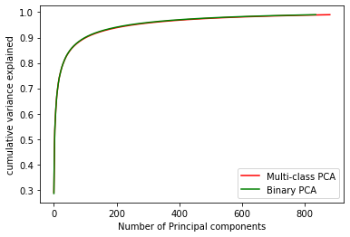

```python
# Comparing variance explained by both PCA
plt.plot(np.cumsum(pca_multi.explained_variance_ratio_), 'red', label='Multi-class PCA')
plt.plot(np.cumsum(pca_binary.explained_variance_ratio_),'green', label='Binary PCA')
plt.legend();
plt.xlabel('Number of Principal components')
plt.ylabel('cumulative variance explained')
plt.show()
```

```python
print(np.cumsum(pca_multi.explained_variance_ratio_)[-5:])
print(np.cumsum(pca_binary.explained_variance_ratio_)[-5:])
```

```
[0.98992763 0.98994974 0.9899718  0.98999374 0.99001563]
[0.9899285  0.98995171 0.98997488 0.98999799 0.99002102]
```

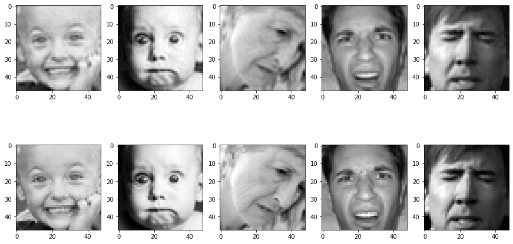

```python
# Inverese the PCA transformed to original for display
inversed_training_2d = pca_multi.inverse_transform(training_pca_transformed)
inveresed_training_3d = inversed_training_2d.reshape(inversed_training_2d.shape[0], 48, 48)

randomlist = random.sample(range(0,inveresed_training_3d.shape[0]), 5)

plt.figure(figsize=(15,8))
for i in range(5):
    plt.subplot(2,5,i+1)
    plt.imshow(inveresed_training_3d[randomlist[i], :], cmap='gray')
    plt.subplot(2,5,i+6)
    plt.imshow(x_training[randomlist[i], :], cmap='gray')
plt.show()
```

> The top 5 images are the PCA inverse transformed images, whereas the bottom 5 are the original ones. It is evident that the top 5 images from the PCA transormation have lost certain clarity due to the reduction technique.